# 12-How-To-Detect-The-Species-Of-An-Iris-Flower-With-Principal-Component-Analysis

### How To Detect The Species Of An Iris Flower With Principal Component Analysis

Scikit-learn includes a data set for Iris flowers.

This data set has 4 features:

- Petal length
- Petal width
- Sepal length
- Sepal width

It also has one target variable with 3 possible values, one for each species of Iris.

Let's say we want to visualize the relationship between these features and their corresponding species.

In order to do this, we will need to "reduce" the 4 dimensions (features) down to 2 or 3 dimensions. For the sake of this example, let's reduce down to 2 dimensions.

Let's start out by loading the Iris data set and examining its number of samples, number of features, and "target names" (species).

```python
from sklearn.datasets import load_iris
from sklearn.decomposition import PCA
import pylab as pl
from itertools import cycle

iris = load_iris()

numSamples, numFeatures = iris.data.shape
print(numSamples)
print(numFeatures)
print(list(iris.target_names))
```

```
150
4
['setosa', 'versicolor', 'virginica']
```

Now let's use scikit-learn's Principal Component Analysis (PCA) function to identify the combination of attributes (principal components, or directions in the feature space) that account for the most variance in our 4-dimensional Iris data.

```python
X = iris.data
pca = PCA(n_components=2, whiten=True).fit(X)
X_pca = pca.transform(X)
```

What do the resulting vectors look like?

```python
print(pca.components_)
```

```
[[ 0.36138659 -0.08452251  0.85667061  0.3582892 ]
 [ 0.65658877  0.73016143 -0.17337266 -0.07548102]]
```

How much variance was captured with just these 2 dimensions?

```python
print(pca.explained_variance_ratio_)
print(sum(pca.explained_variance_ratio_))
```

```
[0.92461872 0.05306648]
0.977685206318795
```

Here's what these numbers are telling us:

- 92% of the variance was captured in the first dimension
- 5% of the variance was captured by the second dimension
- This means that we were able to preserve a total of 97% of the variance while only losing 3% of it by reducing our 4-dimensional data down to 2 dimensions.

Now let's visualize our 2-dimensional data.

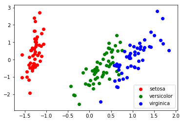

```python
%matplotlib inline
from pylab import *

colors = cycle('rgb')
target_ids = range(len(iris.target_names))
pl.figure()
for i, c, label in zip(target_ids, colors, iris.target_names):
    pl.scatter(X_pca[iris.target == i, 0], X_pca[iris.target == i, 1], c=c, label=label)
pl.legend()
pl.show()
```

The clusters within this plot help us to see that the size of Iris leaves can assist in the classification of Iris species.